# Epiclim Liver Histology analysis - F0 adult females

Baptiste DUcarme

2025-12-10

This script was used to perform liver histopathology analysis in adult female zebrafish (15.5–16.5 months post-fertilization) following developmental exposure (2 hpf to 28 dpf) to combined climate stressors, including acidification (pH 6.35) and elevated temperature (32°C), as well as PFOS exposure (nominal concentration: 2 µg/L), using a 2 × 2 × 2 factorial design.

For each selected section (n = 3-5 per condition), three 250 × 250 µm quadrats of representative tissue were analyzed. Cell density was evaluated using the cell detection analysis tool (QuPath v0.5.1, x64) with detection image set to Hematoxylin OD, background radius of 5µm, and cell expansion of 1µm. The percentage of area occupied by vesicles was then estimated using the pixel threshold tool (threshold = 0.05; resolution = 0.39µm/px). Each section was manually reviewed to exclude veins, bile ducts, and ductules.

To avoid pseudo-replication, statistical analyses were conducted on section-level means of cell density and vesicle area, using a robust linear model following evaluation of residual diagnostic plots. Models included condition and exposure batch as fixed factors (design: ~ condition + exposure). For each outcome, the overall contribution of condition and of exposure was first assessed using robust omnibus F-tests. Pairwise comparisons among conditions were then performed using estimated marginal means (emmeans package). Comparisons against Control were adjusted using Dunnett’s method, and all pairwise comparisons among conditions were adjusted using the BH method. Statistical significance was set at α = 0.05.

To be consistent with other analyses performed during this experiment, histology analysis was restricted to the two exposure common to all conditions (Expo2, Expo3). One individual (PFOSTemp_Expo1), sampled from a previous batch (Expo1), was excluded from downstream analysis, as this exposure contained only this single data point and could not be meaningfully compared across conditions.

A sensitivity analysis confirmed this exclusion did not affect the condition results for either outcome (cell density or vacuole area), and for the Exposure result for cell density. However, for vacuole area, the Exposure effect became statistically significant after excluding Expo1 (from p = 0.056 to p = 0.020) and Exposure batch was therefore retained as a fixed factor.

## 0.1 Working environment setup

```r
setwd("/Users/baptisteducarme/Desktop/EpiCLim-F0-liver-female/Histology")
rm(list = ls()) # clean the global environment, good coding practice

getwd()
```

```
## [1] "/Users/baptisteducarme/Desktop/EpiCLim-F0-liver-female/Histology"
```

```r
list.files()
```

```
## [1] "EPICLIM_F0_Liver_Histology_Females.html"
## [2] "EPICLIM_F0_Liver_Histology_Females.Rmd"
## [3] "EPICLIM_F0_Liver_Histology_Females.xlsx"
```

```r
myColors <- c("Control" = "#4C78A8", "Acid" = "#59A14F", "Temp" = "#E45756","PFOS" = "#B279A2", "AcidTemp" = "#8C6D1F", "PFOSTemp" = "#AD1457", "AcidPFOS" = "#5B6D5B", "AcidPFOSTemp" = "#7B3F5A")
```

# 1 Package

```r
library("readxl") # open data
library("dplyr") # code in pipe
library("ggplot2") # for graph
library("rstatix") # Analyse stat
library("gridExtra") # For graph alignment
library("ggpubr")# for stat link with ggplot
library("lubridate") #for timpoint analysis
library("multcomp")# stat and letter
library('AER')# stat and letter
library("stringr")

library(tidyverse) # includes ggplot2, for data visualisation. dplyr, for data manipulation.
library(RColorBrewer) # for a colourful plot
library(ggrepel) # for nice annotations

R.version
```

```
##                _
## platform       aarch64-apple-darwin20
## arch           aarch64
## os             darwin20
## system         aarch64, darwin20
## status
## major          4
## minor          4.3
## year           2025
## month          02
## day            28
## svn rev        87843
## language       R
## version.string R version 4.4.3 (2025-02-28)
## nickname       Trophy Case
```

# 2 Cells density

```r
Data <- read_excel("/Users/baptisteducarme/Desktop/EpiCLim-F0-liver-female/Histology/EPICLIM_F0_Liver_Histology_Females.xlsx",sheet = "Count_cell")

# Gather cell count by individual to avoid pseudo replication
Data_mean <- aggregate(Num_detection ~ ID + Condition + Expo,data = Data, FUN = mean)

# Sort the data
Data_mean$Condition <- factor(Data_mean$Condition , levels = c("Control","Acid", "Temp", "PFOS", "AcidTemp", "PFOSTemp", "AcidPFOS", "AcidPFOSTemp"))

Data_mean$ID<-as.factor(Data_mean$ID)
Data_mean$Condition<-as.factor(Data_mean$Condition)
Data_mean$Expo<-as.factor(Data_mean$Expo)

# Warning, unballenced design
Data_mean<-Data_mean[Data_mean$Expo != "Expo1",]
Data_mean$Expo <- droplevels(Data_mean$Expo)
Data_mean$Condition <- droplevels(Data_mean$Condition)

table(Data_mean$Condition, Data_mean$Expo)
```

```
##
##                Expo2 Expo3
##   Control          3     2
##   Acid             0     5
##   Temp             0     4
##   PFOS             2     2
##   AcidTemp         1     4
##   PFOSTemp         1     2
##   AcidPFOS         3     2
##   AcidPFOSTemp     4     1
```

```r
Data_mean %>%
  group_by(Condition) %>%
  get_summary_stats(Num_detection, type = "mean_sd")
```

```
## # A tibble: 8 × 5
##   Condition    variable          n  mean    sd
##   <fct>        <fct>         <dbl> <dbl> <dbl>
## 1 Control      Num_detection     5  803.  28.8
## 2 Acid         Num_detection     5  743.  32.8
## 3 Temp         Num_detection     4  787.  23.4
## 4 PFOS         Num_detection     4  839.  44.8
## 5 AcidTemp     Num_detection     5  799.  25.9
## 6 PFOSTemp     Num_detection     3  810.  36.8
## 7 AcidPFOS     Num_detection     5  804.  24.1
## 8 AcidPFOSTemp Num_detection     5  772.  16.4
```

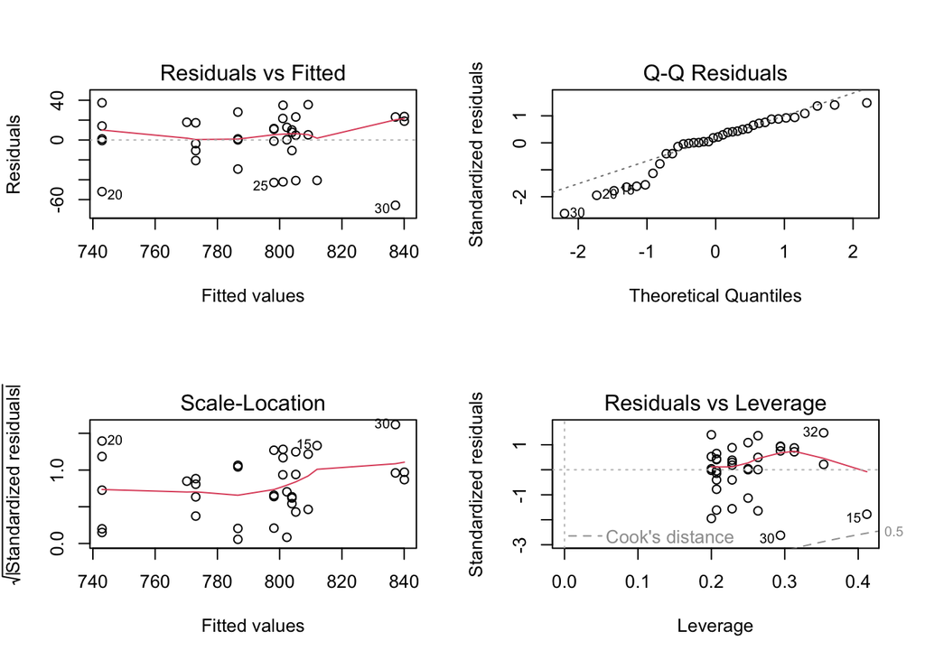

```r
model_1 <- lm(Num_detection ~ Condition + Expo, data = Data_mean)

par(mfrow = c(2, 2))
plot(model_1)
```

```r
par(mfrow = c(1, 1))
```

Switch to rlm.

```r
# robust model
model_2 <- rlm(Num_detection ~ Condition + Expo, data = Data_mean)
names(coef(model_2))
```

```
## [1] "(Intercept)"           "ConditionAcid"         "ConditionTemp"
## [4] "ConditionPFOS"         "ConditionAcidTemp"     "ConditionPFOSTemp"
## [7] "ConditionAcidPFOS"     "ConditionAcidPFOSTemp" "ExpoExpo3"
```

```r
library("sfsmisc")
# Look at the variable contribution to the model
#Omnibus F-test
f.robftest(model_2, var = c("ConditionAcid", "ConditionTemp", "ConditionPFOS","ConditionAcidTemp", "ConditionAcidPFOS", "ConditionPFOSTemp", "ConditionAcidPFOSTemp"))
```

```
##
##  robust F-test (as if non-random weights)
##
## data:  from rlm(formula = Num_detection ~ Condition + Expo, data = Data_mean)
## F = 5.212, p-value = 0.000754
## alternative hypothesis: two.sided
## null values:
##         ConditionAcid         ConditionTemp         ConditionPFOS
##                     0                     0                     0
##     ConditionAcidTemp     ConditionAcidPFOS     ConditionPFOSTemp
##                     0                     0                     0
## ConditionAcidPFOSTemp
##                     0
```

```r
f.robftest(model_2, var = c("ExpoExpo3"))
```

```
##
##  robust F-test (as if non-random weights)
##
## data:  from rlm(formula = Num_detection ~ Condition + Expo, data = Data_mean)
## F = 0.0049831, p-value = 0.9442
## alternative hypothesis: true ExpoExpo3 is not equal to 0
```

The condition significantly contributed to the model (p-value = 0.000754 < 0.05), whereas no evidence Exposure explains additional variation once Condition is in the model (p-value = 0.9442).

```r
library("emmeans")
emm_pooled <- emmeans(model_2, ~ Condition)
contrast(emm_pooled, method = "trt.vs.ctrl", ref = "Control", adjust = "dunnett")
```

```
##  contrast               estimate   SE df z.ratio p.value
##  Acid - Control           -59.41 19.1 NA  -3.106  0.0120
##  Temp - Control           -20.02 20.1 NA  -0.994  0.8079
##  PFOS - Control            47.89 18.9 NA   2.536  0.0639
##  AcidTemp - Control        -2.26 18.4 NA  -0.123  0.9997
##  PFOSTemp - Control         7.14 20.8 NA   0.344  0.9921
##  AcidPFOS - Control         2.26 17.8 NA   0.127  0.9997
##  AcidPFOSTemp - Control   -33.91 17.9 NA  -1.892  0.2689
##
## Results are averaged over the levels of: Expo
## P value adjustment: dunnettx method for 7 tests
```

```r
#All pairwise comparison
pairs(emm_pooled, adjust = "BH")
```

```
##  contrast                estimate   SE df z.ratio p.value
##  Control - Acid             59.41 19.1 NA   3.106  0.0076
##  Control - Temp             20.02 20.1 NA   0.994  0.4480
##  Control - PFOS            -47.89 18.9 NA  -2.536  0.0348
##  Control - AcidTemp          2.26 18.4 NA   0.123  0.9023
##  Control - PFOSTemp         -7.14 20.8 NA  -0.344  0.8527
##  Control - AcidPFOS         -2.26 17.8 NA  -0.127  0.9023
##  Control - AcidPFOSTemp     33.91 17.9 NA   1.892  0.1093
##  Acid - Temp               -39.39 18.8 NA  -2.090  0.0932
##  Acid - PFOS              -107.30 19.7 NA  -5.434  <.0001
##  Acid - AcidTemp           -57.15 17.9 NA  -3.189  0.0067
##  Acid - PFOSTemp           -66.55 20.9 NA  -3.186  0.0067
##  Acid - AcidPFOS           -61.67 19.1 NA  -3.224  0.0067
##  Acid - AcidPFOSTemp       -25.49 20.1 NA  -1.267  0.3315
##  Temp - PFOS               -67.91 20.7 NA  -3.277  0.0067
##  Temp - AcidTemp           -17.76 19.0 NA  -0.935  0.4662
##  Temp - PFOSTemp           -27.16 21.8 NA  -1.245  0.3315
##  Temp - AcidPFOS           -22.28 20.1 NA  -1.107  0.3955
##  Temp - AcidPFOSTemp        13.89 21.1 NA   0.659  0.6488
##  PFOS - AcidTemp            50.15 19.2 NA   2.615  0.0312
##  PFOS - PFOSTemp            40.75 21.5 NA   1.891  0.1093
##  PFOS - AcidPFOS            45.63 18.9 NA   2.417  0.0439
##  PFOS - AcidPFOSTemp        81.81 19.2 NA   4.266  0.0003
##  AcidTemp - PFOSTemp        -9.40 20.6 NA  -0.457  0.7887
##  AcidTemp - AcidPFOS        -4.52 18.4 NA  -0.246  0.8768
##  AcidTemp - AcidPFOSTemp    31.66 19.1 NA   1.655  0.1713
##  PFOSTemp - AcidPFOS         4.88 20.8 NA   0.235  0.8768
##  PFOSTemp - AcidPFOSTemp    41.05 21.2 NA   1.933  0.1093
##  AcidPFOS - AcidPFOSTemp    36.18 17.9 NA   2.018  0.1016
##
## Results are averaged over the levels of: Expo
## P value adjustment: BH method for 28 tests
```

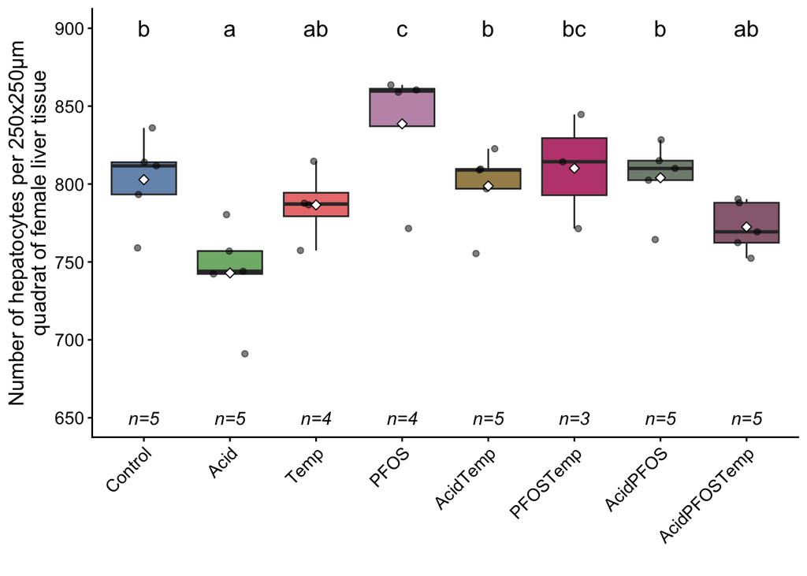

```r
# BH compact letters
cld_df <- as.data.frame(cld(emm_pooled, Letters = letters, adjust = "BH"))
cld_df$.group <- trimws(cld_df$.group)

# Sample sizes
n_df <- Data_mean %>%
  filter(!is.na(Num_detection)) %>%
  group_by(Condition) %>%
  summarise(n = n(), .groups = "drop")
n_df$label <- paste0("n=", n_df$n)

# Plot
plot1<-ggplot(Data_mean, aes(x = Condition, y = Num_detection, fill = Condition)) +
  geom_boxplot(alpha = 0.8, outlier.shape = NA) +
  geom_jitter(width = 0.2, size = 1.5, alpha = 0.5) +
  stat_summary(fun = mean, geom = "point", shape = 23, size = 2, fill = "white") +
  scale_fill_manual(values = myColors) +
  geom_text(data = cld_df, aes(x = Condition, y = 900, label = .group),
            size = 5, inherit.aes = FALSE) +
  geom_text(data = n_df, aes(x = Condition, y = 650, label = label),
            size = 4, fontface = "italic", inherit.aes = FALSE) +
  labs(y = "Number of hepatocytes per 250x250µm
       quadrat of female liver tissue", x = "") +
  theme_classic() +
  theme(legend.position = "none",
        axis.text.x = element_text(angle = 45, hjust = 1, size = 11),
        axis.text.y = element_text(size = 11),
        axis.title.y = element_text(size = 13),
        plot.title = element_text(size = 14, face = "bold"))

plot1
```

*Figure 1. Female liver histopathology:* Mean hepatocyte density per 250 × 250 µm quadrat.

# 3 Lipid %

```r
Data <- read_excel("/Users/baptisteducarme/Desktop/EpiCLim-F0-liver-female/Histology/EPICLIM_F0_Liver_Histology_Females.xlsx",sheet = "Vacuolization")
head(Data)
```

```
## # A tibble: 6 × 5
##   ID               Condition Expo  RepeatMeasure Pourcentage
##   <chr>            <chr>     <chr>         <dbl>       <dbl>
## 1 Control Expo 2b  Control   Expo2             1        7.53
## 2 Control Expo 2b  Control   Expo2             2        7.48
## 3 Control Expo 2b  Control   Expo2             3        5.40
## 4 Control_Expo2_1b Control   Expo2             1        5.71
## 5 Control_Expo2_1b Control   Expo2             2        5.82
## 6 Control_Expo2_1b Control   Expo2             3        7.37
```

```r
# Gather the semi-quantitative lipid content by individual to avoid pseudo replication
Data_mean <- aggregate(Pourcentage ~ ID + Condition + Expo,data = Data, FUN = mean)

# Sort the data
Data_mean$Condition <- factor(Data_mean$Condition , levels = c("Control","Acid", "Temp", "PFOS", "AcidTemp", "PFOSTemp", "AcidPFOS", "AcidPFOSTemp"))

Data_mean$ID<-as.factor(Data_mean$ID)
Data_mean$Condition<-as.factor(Data_mean$Condition)
Data_mean$Expo<-as.factor(Data_mean$Expo)

# Warning, unballenced design
Data_mean<-Data_mean[Data_mean$Expo != "Expo1",]
Data_mean$Expo <- droplevels(Data_mean$Expo)
Data_mean$Condition <- droplevels(Data_mean$Condition)

table(Data_mean$Condition, Data_mean$Expo)
```

```
##
##                Expo2 Expo3
##   Control          3     2
##   Acid             0     5
##   Temp             0     4
##   PFOS             2     2
##   AcidTemp         1     4
##   PFOSTemp         1     2
##   AcidPFOS         3     2
##   AcidPFOSTemp     4     1
```

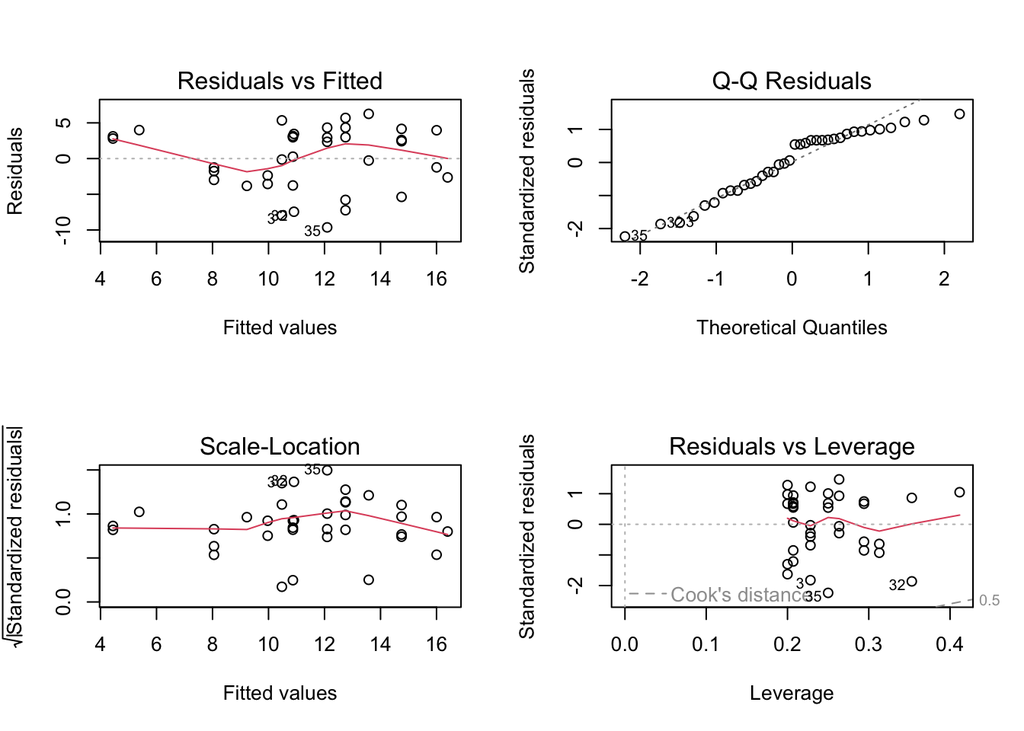

```r
model_1 <- lm(Pourcentage ~ Condition + Expo, data = Data_mean)

par(mfrow = c(2, 2))
plot(model_1)
```

```r
par(mfrow = c(1, 1))
```

Idem, switch to rlm

```r
# robust model
model_2 <- rlm(Pourcentage ~ Condition + Expo, data = Data_mean)
names(coef(model_2))
```

```
## [1] "(Intercept)"           "ConditionAcid"         "ConditionTemp"
## [4] "ConditionPFOS"         "ConditionAcidTemp"     "ConditionPFOSTemp"
## [7] "ConditionAcidPFOS"     "ConditionAcidPFOSTemp" "ExpoExpo3"
```

```r
library("sfsmisc")
# Look at the variable contribution to the model
#Omnibus F-test
f.robftest(model_2, var = c("ConditionAcid", "ConditionTemp", "ConditionPFOS","ConditionAcidTemp", "ConditionAcidPFOS", "ConditionPFOSTemp", "ConditionAcidPFOSTemp"))
```

```
##
##  robust F-test (as if non-random weights)
##
## data:  from rlm(formula = Pourcentage ~ Condition + Expo, data = Data_mean)
## F = 0.74373, p-value = 0.6376
## alternative hypothesis: two.sided
## null values:
##         ConditionAcid         ConditionTemp         ConditionPFOS
##                     0                     0                     0
##     ConditionAcidTemp     ConditionAcidPFOS     ConditionPFOSTemp
##                     0                     0                     0
## ConditionAcidPFOSTemp
##                     0
```

```r
f.robftest(model_2, var = c("ExpoExpo3"))
```

```
##
##  robust F-test (as if non-random weights)
##
## data:  from rlm(formula = Pourcentage ~ Condition + Expo, data = Data_mean)
## F = 6.1203, p-value = 0.01994
## alternative hypothesis: true ExpoExpo3 is not equal to 0
```

Condition did not significantly explain variation in vacuole area % once Expo was accounted for (F = 0.74373, p-value = 0.6376). Expo showed a significant effect (F = 6.1203, p-value = 0.01994). The two exposure batches were therefore retained as fixed factor.

```r
#All pairwise comparison
emm_pooled <- emmeans(model_2, ~ Condition)
contrast(emm_pooled, method = "trt.vs.ctrl", ref = "Control", adjust = "dunnett")
```

```
##  contrast               estimate   SE df z.ratio p.value
##  Acid - Control           -0.512 3.61 NA  -0.142  0.9995
##  Temp - Control           -0.281 3.80 NA  -0.074  0.9999
##  PFOS - Control           -3.580 3.56 NA  -1.004  0.8029
##  AcidTemp - Control        1.221 3.47 NA   0.352  0.9915
##  PFOSTemp - Control       -2.023 3.92 NA  -0.516  0.9717
##  AcidPFOS - Control        2.891 3.35 NA   0.862  0.8702
##  AcidPFOSTemp - Control    2.829 3.38 NA   0.836  0.8810
##
## Results are averaged over the levels of: Expo
## P value adjustment: dunnettx method for 7 tests
```

```r
#All pairwise comparison
pairs(emm_pooled, adjust = "BH")
```

```
##  contrast                estimate   SE df z.ratio p.value
##  Control - Acid            0.5124 3.61 NA   0.142  0.9834
##  Control - Temp            0.2815 3.80 NA   0.074  0.9834
##  Control - PFOS            3.5797 3.56 NA   1.004  0.8110
##  Control - AcidTemp       -1.2206 3.47 NA  -0.352  0.8459
##  Control - PFOSTemp        2.0229 3.92 NA   0.516  0.8459
##  Control - AcidPFOS       -2.8913 3.35 NA  -0.862  0.8110
##  Control - AcidPFOSTemp   -2.8288 3.38 NA  -0.836  0.8110
##  Acid - Temp              -0.2310 3.56 NA  -0.065  0.9834
##  Acid - PFOS               3.0673 3.73 NA   0.823  0.8110
##  Acid - AcidTemp          -1.7330 3.38 NA  -0.512  0.8459
##  Acid - PFOSTemp           1.5104 3.94 NA   0.383  0.8459
##  Acid - AcidPFOS          -3.4038 3.61 NA  -0.943  0.8110
##  Acid - AcidPFOSTemp      -3.3412 3.80 NA  -0.880  0.8110
##  Temp - PFOS               3.2982 3.91 NA   0.843  0.8110
##  Temp - AcidTemp          -1.5021 3.59 NA  -0.419  0.8459
##  Temp - PFOSTemp           1.7414 4.12 NA   0.423  0.8459
##  Temp - AcidPFOS          -3.1728 3.80 NA  -0.835  0.8110
##  Temp - AcidPFOSTemp      -3.1102 3.98 NA  -0.782  0.8110
##  PFOS - AcidTemp          -4.8003 3.62 NA  -1.326  0.8110
##  PFOS - PFOSTemp          -1.5568 4.07 NA  -0.383  0.8459
##  PFOS - AcidPFOS          -6.4710 3.56 NA  -1.815  0.8110
##  PFOS - AcidPFOSTemp      -6.4085 3.62 NA  -1.770  0.8110
##  AcidTemp - PFOSTemp       3.2434 3.88 NA   0.835  0.8110
##  AcidTemp - AcidPFOS      -1.6708 3.47 NA  -0.481  0.8459
##  AcidTemp - AcidPFOSTemp  -1.6082 3.61 NA  -0.445  0.8459
##  PFOSTemp - AcidPFOS      -4.9142 3.92 NA  -1.254  0.8110
##  PFOSTemp - AcidPFOSTemp  -4.8516 4.01 NA  -1.210  0.8110
##  AcidPFOS - AcidPFOSTemp   0.0626 3.38 NA   0.018  0.9852
##
## Results are averaged over the levels of: Expo
## P value adjustment: BH method for 28 tests
```

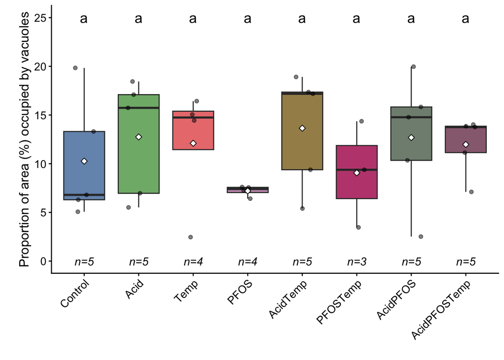

```r
# BH compact letters
cld_df <- as.data.frame(cld(emm_pooled, Letters = letters, adjust = "BH"))
cld_df$.group <- trimws(cld_df$.group)

# Sample sizes
n_df <- Data_mean %>%
  filter(!is.na(Pourcentage)) %>%
  group_by(Condition) %>%
  summarise(n = n(), .groups = "drop")
n_df$label <- paste0("n=", n_df$n)

# Plot
plot2<-ggplot(Data_mean, aes(x = Condition, y = Pourcentage, fill = Condition)) +
  geom_boxplot(alpha = 0.8, outlier.shape = NA) +
  geom_jitter(width = 0.2, size = 1.5, alpha = 0.5) +
  stat_summary(fun = mean, geom = "point", shape = 23, size = 2, fill = "white") +
  scale_fill_manual(values = myColors) +
  geom_text(data = cld_df, aes(x = Condition, y = 25, label = .group),
            size = 5, inherit.aes = FALSE) +
  geom_text(data = n_df, aes(x = Condition, y = 0, label = label),
            size = 4, fontface = "italic", inherit.aes = FALSE) +
 labs(y = "\nProportion of area (%) occupied by vacuoles", x = "")+
  theme_classic() +
  theme(legend.position = "none",
        axis.text.x = element_text(angle = 45, hjust = 1, size = 11),
        axis.text.y = element_text(size = 11),
        axis.title.y = element_text(size = 13),
        plot.title = element_text(size = 14, face = "bold"))

plot2
```

*Figure 2. Female liver histopathology:* Mean proportion of area (%) occupied by vacuoles per 250 × 250 µm quadrat.

# 4 Sensitivity check

## 4.1 Cell density

```r
Data <- read_excel("/Users/baptisteducarme/Desktop/EpiCLim-F0-liver-female/Histology/EPICLIM_F0_Liver_Histology_Females.xlsx",sheet = "Count_cell")
# Gather cell count by individual to avoid pseudo replication
Data_mean <- aggregate(Num_detection ~ ID + Condition + Expo,data = Data, FUN = mean)

# Sort the data
Data_mean$Condition <- factor(Data_mean$Condition , levels = c("Control","Acid", "Temp", "PFOS", "AcidTemp", "PFOSTemp", "AcidPFOS", "AcidPFOSTemp"))

Data_mean$ID<-as.factor(Data_mean$ID)
Data_mean$Condition<-as.factor(Data_mean$Condition)
Data_mean$Expo<-as.factor(Data_mean$Expo)

# Model full
Data_Expo123<-Data_mean

# Restricted model
Data_Expo23<-Data_Expo123[Data_Expo123$Expo != "Expo1",]
Data_Expo23$Expo <- droplevels(Data_Expo23$Expo)
Data_Expo23$Condition <- droplevels(Data_Expo23$Condition)
```

```r
model_Full <- rlm(Num_detection ~ Condition + Expo, data = Data_Expo123) # with expo1
model_Restricted <- rlm(Num_detection ~ Condition + Expo, data = Data_Expo23) # without expo1
```

```r
library("sfsmisc")

### Condition
f.robftest(model_Full, var = c("ConditionAcid", "ConditionTemp", "ConditionPFOS","ConditionAcidTemp", "ConditionAcidPFOS", "ConditionPFOSTemp", "ConditionAcidPFOSTemp"))
```

```
##
##  robust F-test (as if non-random weights)
##
## data:  from rlm(formula = Num_detection ~ Condition + Expo, data = Data_Expo123)
## F = 5.8253, p-value = 0.0003448
## alternative hypothesis: two.sided
## null values:
##         ConditionAcid         ConditionTemp         ConditionPFOS
##                     0                     0                     0
##     ConditionAcidTemp     ConditionAcidPFOS     ConditionPFOSTemp
##                     0                     0                     0
## ConditionAcidPFOSTemp
##                     0
```

```r
f.robftest(model_Restricted, var = c("ConditionAcid", "ConditionTemp", "ConditionPFOS","ConditionAcidTemp", "ConditionAcidPFOS", "ConditionPFOSTemp", "ConditionAcidPFOSTemp"))
```

```
##
##  robust F-test (as if non-random weights)
##
## data:  from rlm(formula = Num_detection ~ Condition + Expo, data = Data_Expo23)
## F = 5.212, p-value = 0.000754
## alternative hypothesis: two.sided
## null values:
##         ConditionAcid         ConditionTemp         ConditionPFOS
##                     0                     0                     0
##     ConditionAcidTemp     ConditionAcidPFOS     ConditionPFOSTemp
##                     0                     0                     0
## ConditionAcidPFOSTemp
##                     0
```

```r
### Exposure
f.robftest(model_Full, var = c("ExpoExpo2","ExpoExpo3"))
```

```
##
##  robust F-test (as if non-random weights)
##
## data:  from rlm(formula = Num_detection ~ Condition + Expo, data = Data_Expo123)
## F = 0.25557, p-value = 0.7763
## alternative hypothesis: two.sided
## null values:
## ExpoExpo2 ExpoExpo3
##         0         0
```

```r
f.robftest(model_Restricted, var = c("ExpoExpo3"))
```

```
##
##  robust F-test (as if non-random weights)
##
## data:  from rlm(formula = Num_detection ~ Condition + Expo, data = Data_Expo23)
## F = 0.0049831, p-value = 0.9442
## alternative hypothesis: true ExpoExpo3 is not equal to 0
```

Sensitivity analysis show that excluding the single Expo1 individual did not qualitatively change the results. The Condition effect remained highly significant in both the full (F = 5.83, p < 0.001) and restricted (F = 5.21, p < 0.001) datasets, while Exposure batch remained non-significant in both (full: p = 0.776; restricted: p = 0.944).

## 4.2 Lipid %

```r
Data <- read_excel("/Users/baptisteducarme/Desktop/EpiCLim-F0-liver-female/Histology/EPICLIM_F0_Liver_Histology_Females.xlsx",sheet = "Vacuolization")

# Gather cell count by individual to avoid pseudo replication
Data_mean <- aggregate(Pourcentage ~ ID + Condition + Expo,data = Data, FUN = mean)

# Sort the data
Data_mean$Condition <- factor(Data_mean$Condition , levels = c("Control","Acid", "Temp", "PFOS", "AcidTemp", "PFOSTemp", "AcidPFOS", "AcidPFOSTemp"))

Data_mean$ID<-as.factor(Data_mean$ID)
Data_mean$Condition<-as.factor(Data_mean$Condition)
Data_mean$Expo<-as.factor(Data_mean$Expo)

# Model full
Data_Expo123<-Data_mean

# Restricted model
Data_Expo23<-Data_Expo123[Data_Expo123$Expo != "Expo1",]
Data_Expo23$Expo <- droplevels(Data_Expo23$Expo)
Data_Expo23$Condition <- droplevels(Data_Expo23$Condition)
```

```r
model_Full <- rlm(Pourcentage ~ Condition + Expo, data = Data_Expo123) # with expo1
model_Restricted <- rlm(Pourcentage ~ Condition + Expo, data = Data_Expo23) # without expo1
```

```r
### Condition
library("sfsmisc")
f.robftest(model_Full, var = c("ConditionAcid", "ConditionTemp", "ConditionPFOS","ConditionAcidTemp", "ConditionAcidPFOS", "ConditionPFOSTemp", "ConditionAcidPFOSTemp"))
```

```
##
##  robust F-test (as if non-random weights)
##
## data:  from rlm(formula = Pourcentage ~ Condition + Expo, data = Data_Expo123)
## F = 0.75467, p-value = 0.6291
## alternative hypothesis: two.sided
## null values:
##         ConditionAcid         ConditionTemp         ConditionPFOS
##                     0                     0                     0
##     ConditionAcidTemp     ConditionAcidPFOS     ConditionPFOSTemp
##                     0                     0                     0
## ConditionAcidPFOSTemp
##                     0
```

```r
f.robftest(model_Restricted, var = c("ConditionAcid", "ConditionTemp", "ConditionPFOS","ConditionAcidTemp", "ConditionAcidPFOS", "ConditionPFOSTemp", "ConditionAcidPFOSTemp"))
```

```
##
##  robust F-test (as if non-random weights)
##
## data:  from rlm(formula = Pourcentage ~ Condition + Expo, data = Data_Expo23)
## F = 0.74373, p-value = 0.6376
## alternative hypothesis: two.sided
## null values:
##         ConditionAcid         ConditionTemp         ConditionPFOS
##                     0                     0                     0
##     ConditionAcidTemp     ConditionAcidPFOS     ConditionPFOSTemp
##                     0                     0                     0
## ConditionAcidPFOSTemp
##                     0
```

```r
### Exposure
library("sfsmisc")
f.robftest(model_Full, var = c("ExpoExpo2","ExpoExpo3"))
```

```
##
##  robust F-test (as if non-random weights)
##
## data:  from rlm(formula = Pourcentage ~ Condition + Expo, data = Data_Expo123)
## F = 3.2131, p-value = 0.05601
## alternative hypothesis: two.sided
## null values:
## ExpoExpo2 ExpoExpo3
##         0         0
```

```r
f.robftest(model_Restricted, var = c("ExpoExpo3"))
```

```
##
##  robust F-test (as if non-random weights)
##
## data:  from rlm(formula = Pourcentage ~ Condition + Expo, data = Data_Expo23)
## F = 6.1203, p-value = 0.01994
## alternative hypothesis: true ExpoExpo3 is not equal to 0
```

Condition does not significantly explain variation in vacuole area %, with or without the Expo1 individual.